# Coursework Report

*N* removed NAs: 2

*N* removed typo: 1

*N* removed <18: 22

*N* total clean: 125

| Group | *N* | *M*<sub>age</sub> | *M*<sub>rating</sub> |
| --- | --- | --- | --- |
| Control | 61 | 21.0 | 7.28 |
| Experim | 64 | 21.4 | 5.69 |

**Main analysis results**

*t*(123) = 10.92, *p* < .001

[interactive chart not shown]

[figure not shown]

[interactive chart not shown]

# Coursework Report

Analysing Data, Spring 2020

# Methods

## Participants

This study was conducted on 125 psychchology undergraduates from University of Sussex who paricipated voluntarily. The mean age of participants was 21.21 (*SD*<sub>age</sub> = 2.03). Data from 22 participants were removed due to unethial participant ages. Data from one participant was removed due to an error in how they reported their age, causing it to be invalid. Initially there were 150 participants. Figure 1 displays information about the ages of participants, and Figure 2 shows the distribution of ages in each condition of the study.

Table 1: *Decsriptive statistics by age*

| *M*<sub>age</sub> | *SD*<sub>Age</sub> | *Min*<sub>age</sub> | *Max*<sub>age</sub> |
| --- | --- | --- | --- |
| 21.2 | 2.03 | 18 | 27 |

Table 2: *Descriptive statistics of age by condition*

| Condition | *N* | % | *M*<sub>age</sub> | *SD*<sub>age</sub> |
| --- | --- | --- | --- | --- |
| Control | 61 | 48.8 | 21.0 | 2.26 |
| Experimental | 64 | 51.2 | 21.4 | 1.80 |

## Design

The conceptual hypothesis is that colour influences women’s perception of men’s attractiveness. Participants were shown a photo of a moderately attractive, young, caucasian man on either a red or white background. Particiapants were randomly allocated to either the experimental condition, in which they saw the photo on a red background, or the control condition, in which participants saw the photo on a white background. The independent variable was therefore which colour background the photo was presented on, which is a factor with two levels. The dependent variable is the participants perception of attractiveness, which is assessed using three items: “How attractive do you think this person is?”, “how pleasant is this person to look at?”, and “if I were to meet the person in this picutre face to face, I would think he is attractive”. Each of these items were rated on a scale from 1 (not at all attractive) to 9 (extremely attractive). Scores from each of these items were then averaged to create a composite score. The operational hypothesis is that women have a higher composite score rating a man’s attractiveness when his photo is seen on a red background rather than a white one. I will use a t-test in order to test this hypothesis.

# Results

Using an independent-measures *t*-test, I investigated whether people would rate men as more attarctive when seen on a red background. The means in the two conditions were quite different (*M*<sub>diff</sub> = 1.59, 95% CI [1.3, 1.87]) and there was a significant difference between the two groups on ratings of perceived attractiveness (*t* (123) = 10.92, *p* < .001. This suggests participants found men more attractive when they were seen on a white background. Figure 3 shows the difference in the mean rating of attractiveness in both conditions, again showing that men were rated as more attractive on the white bachground.

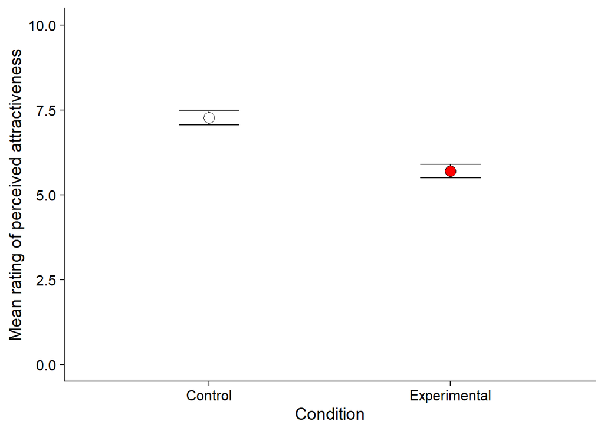

# Discussion

# References

Elliot, A. J., Niesta Kayser, D., Greitemeyer, T., Lichtenfeld, S., Gramzow, R. H., Maier, M. A., & Liu, H. (2010). Red, rank, and romance in women viewing men. Journal of Experimental Psychology: General, 139(3), 399–417. https://doi.org/10.1037/a0019689